# Registro de datos de la ciudadania digital en Bolivia

Maestría en Administración de Empresas

Grupo 10

27/1/2022

### Estadisticas del registro de la ciudadania Digital en Bolivia

## Integrantes

1. Omar Valdez Muñoz omar@outlook.com
2. Oscar Marcelo Castellon Borda o.castellon12@gmail.com
3. Marcelo Rodriguez Gomez marcelorodriguezgomezmrg@gmail.com
4. Dave daveveliz03@gmail.com
5. Celia Fuertes Zegarra ccfuertes@gmail.com

# ANTECEDENTES

La ciudadanía digital consiste en el ejercicio de derechos y deberes a través del uso de tecnologías de información y comunicación en la interacción de las personas con las entidades públicas y privadas que presten servicios públicos delegados por el Estado, que permitirá brindar información personal, laboral, social, etc. Así mismo servirá como un canal de comunicación e información valida, segura y confiable, entre el Estado y la población, donde toda la población boliviana y persona extranjera podrá interactuar y participar con el Estado y demás entidades o empresas públicas y privadas.

## Beneficios

Mediante un buzón electrónico la población podrá alojar historiales médicos, académicos, laborales, antecedentes y cualquier otra información de interés del usuario, el cual permitirá la integración y la interoperabilidad entre los distintos sistemas gubernamentales y privados.

La plataforma de Ciudadanía Digital será accesible en línea en cualquier momento desde cualquier lugar y mediante cualquier terminal que disponga del servicio de acceso a internet.

# OBJETIVO

Implementar la plataforma de Ciudadanía Digital, para facilitar la interacción y el acceso de la población a los servicios digitales, optimizando costos y tiempo y mejorando la calidad de los servicios del Estado y empresas públicas y privadas teniendo las siguientes herramientas:

· Buzón digital de documentos personales.

· Canal de Comunicación entre el Estado y la población.

· Canal de consultas participativas, mediante el cual se recopilará la opinión de la población.

· Desarrollo de la normativa correspondiente para la reglamentación y legalidad de la plataforma.

· Herramienta para facilitar operaciones de Comercio y Gobierno Electrónico.

· Alojamientos de documentos firmados digitalmente.

# FUNCIONES

La ciudadanía digital es un espacio que contendrá toda la información necesaria y documentos firmados digitalmente que cada persona requiera, la cual podrá ser utilizada por distintas instancias donde el usuario podrá hacer uso de la información según los requerimientos de los servicios que el Estado brinda hacia la población, como ser trámites administrativos, legales, entre otros.

El Estado podrá realizar consultas a la población, para mejorar el desarrollo de políticas públicas, la calidad de servicio a la población y otros temas de interés. Así mismo esta herramienta servirá como medio de sugerencias, iniciativas y propuesta por parte de la población para el vivir bien, mejorando un acercamiento directo entre población y Estado.

El programa tendrá un sustento legal mediante el desarrollo de la normativa con el fin incentivar y validar el uso de esta plataforma como una herramienta diaria de la población.

La plataforma Ciudadanía Digital permitirá realizar la integración con distintos servicios digitales, como ser transacciones de Comercio electrónico y otros servicios que surjan como necesidad de la población.

## Marco teórico Actualmente, la sociedad se encuentra experimentando cambios radicales en los modelos económicos e industriales, así como en los bienes y servicios, gracias a la aparición del desarrollo de las tecnologías de la información y la comunicación, junto con el avance de las ciencias. Es así como, según lo afirma J. Ignacio Aguaded Gómez especialista en tecnología educativa (1999) la tecnología de la información se convirtió en la infraestructura primaria de toda sociedad.

Así como la sociedad se transforma, junto con los cambios que experimenta en su ambiente, el ser humano también lo tiene que hacer; y como individuo y ciudadano que es, debe adaptarse y aprender nuevas herramientas que le permitan ser útil en ese nuevo ámbito y es así como surge la ciudadanía digital. “La ciudadanía digital” podría definirse según indican Ribble, Bailey y Ross [2004] como las “normas de comportamiento que conciernen al uso de la tecnología” y englobaría” los problemas del uso, mal uso y abuso de la tecnología”.

### ¿Que es la ciudadanía digital?

“Es Es el conjunto de conocimientos, habilidades y actitudes fundamentales para que niños, niñas, jóvenes y adultos se desenvuelvan en una sociedad democrática a través del uso de las Tecnologías de Información y Comunicación, de manera responsable, informada, segura, ética, libre y participativa, ejerciendo y reconociendo sus derechos digitales y comprendiendo el impacto de éstas en su vida personal y su entorno”

### Características de la Ciudadanía Digital

Una ciudad inteligente es considerada como tal cuando posee las siguientes características:

1. Incorporación de la tecnología de información y comunicación (TIC) a los servicios públicos. Esto permite facilitar la transparencia, velocidad y participación en los servicios públicos.
2. Empresas de servicios eficientes. Se refiere el uso de los siguientes aspectos:

· Uso de contadores inteligentes

· Manejo de energías renovables

· Recolección adecuada de agua

· Métodos adecuados de eliminación de residuos sólidos

3. Uso creativo de las asociaciones público-privadas. Importantes porque son una fuente de capital, así como su uso, pues es destinado a la prestación de los servicios públicos y el control del cumplimiento de los estándares del mismo.
4. Protección y seguridad. Incorpora el uso de: cámaras de vigilancia, iluminación de zonas públicas, patrullaje, verificación de identidad de los ciudadanos, respuesta S.O.S.
5. Sustentabilidad financiera. Esta es posible cuando se es realizada una planificación pertinente y extensa del uso de todas las fuentes de ingresos como lo son los impuestos de propiedad, anuncios por pago, etc.
6. Participación ciudadana en el gobierno. Para esto es necesario un diseño de foros electorales y participativos como escuelas, lugares comerciales, entretenimiento, áreas públicas, entre otros.
7. Capital social. Fundamental el nivel apropiado de infraestructuras como lo son: lugares comerciales, lugares deportivos, áreas comunes, hospitales, escuelas, etc.
8. Planificación del tránsito. Hace referencia a la conectividad que existe en la red de transporte público, lo que causa una reducción en el uso de vehículos particulares, en donde se busca la implementación del uso de coches eléctricos y vías destinadas para el uso de bicicletas.
9. Características ecológicas. Se busca proteger el medio ambiente mediante mecanismos que contrarresten el uso de carbono, implementando espacios abiertos verdes, el uso del reciclaje, el uso de energías renovables y la conservación del medio ambiente

### Características De Un Ciudadano Inteligente

En vista de que el ciudadano actual debe adquirir ciertas habilidades para mantenerse activo en este nuevo modelo de producción y empresarial, tendrá que priorizar su aprendizaje en los siguientes aspectos:

1. Habilidades de información y comunicación, comúnmente conocido como alfabetización digital. “Tal alfabetización desde nuestro punto de vista, debe facilitar la creación de personas competentes al menos en tres aspectos básicos: manejar instrumentalmente las tecnologías, tener actitudes positivas y realistas para su utilización, y saber evaluar sus mensajes y sus necesidades de utilización.”, es decir, no solo destrezas de tipo instrumental -que sin duda hay que adquirirlas-, sino ir más allá́, al campo de las destrezas cognitivas.
2. Habilidades de pensamiento y de solución de problemas. A esto se refiere el pensamiento crítico que debe desarrollar un ciudadano con el objetivo de que pueda identificar, formular y solucionar problemas, de forma que pueda opinar y tomar una posición respecto a todo aquello que se va encontrando en la búsqueda de información.

3.Habilidades interpersonales y de autonomía gracias a los cambios en la sociedad mencionados previamente, la organización empresarial deja a un lado su estructura jerarquizada por una horizontal, de modo que el hombre deberá replantear sus habilidades de colaboración, trabajo en equipo, autorregulación, entre otros.

# ANALISIS DE REGISTRO DE TRAMITES DIGITALES EN BOLIVIA

Durante las gestiones 2020 y 2021 se registro datos del uso de la ciudadania digital, lanzando la siguiente informacion:

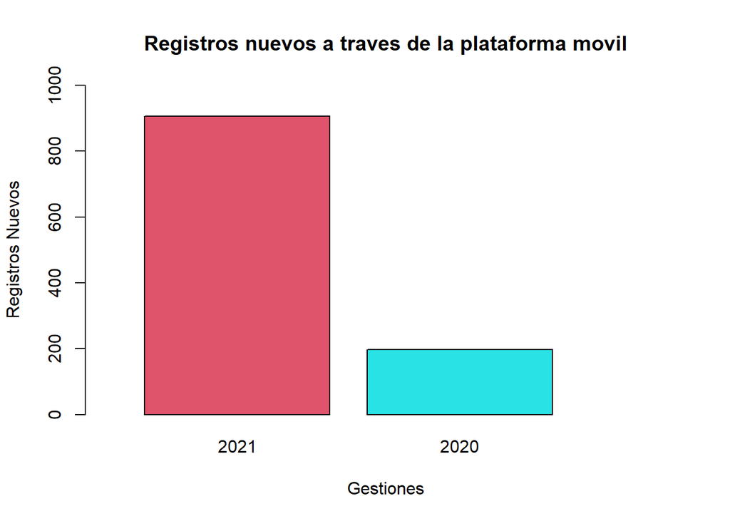

```r
# Cantidad de registros nuevos por la plataforma movil
bp1 <- read.table("preregistros_portal_v2.csv", header=TRUE, sep=";", stringsAsFactors = FALSE)
barplot( bp1$cantidad_movil ,xlab="Gestiones", ylab="Registros Nuevos", xlim = c(0,3),ylim = c(0,1000), names=(bp1$gestion), main = 'Registros nuevos a traves de la plataforma movil',col = c(2,5,7))
```

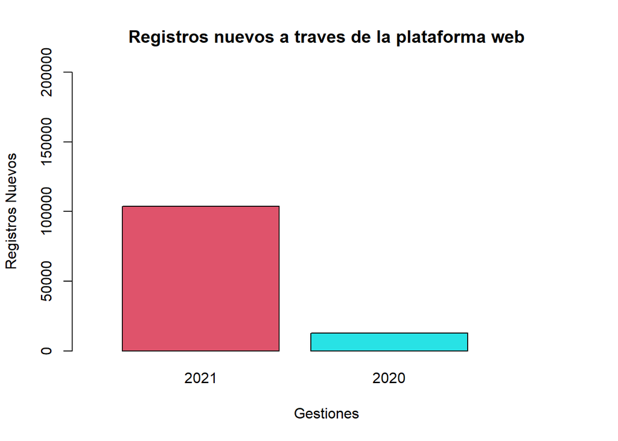

```r
# Cantidad de registros nuevos por la plataforma web
bp1 <- read.table("preregistros_portal_v2.csv", header=TRUE, sep=";", stringsAsFactors = FALSE)
barplot( bp1$cantidad_web ,xlab="Gestiones", ylab="Registros Nuevos", xlim = c(0,3),ylim = c(0,200000), names=(bp1$gestion), main = 'Registros nuevos a traves de la plataforma web',col = c(2,5,7))
```

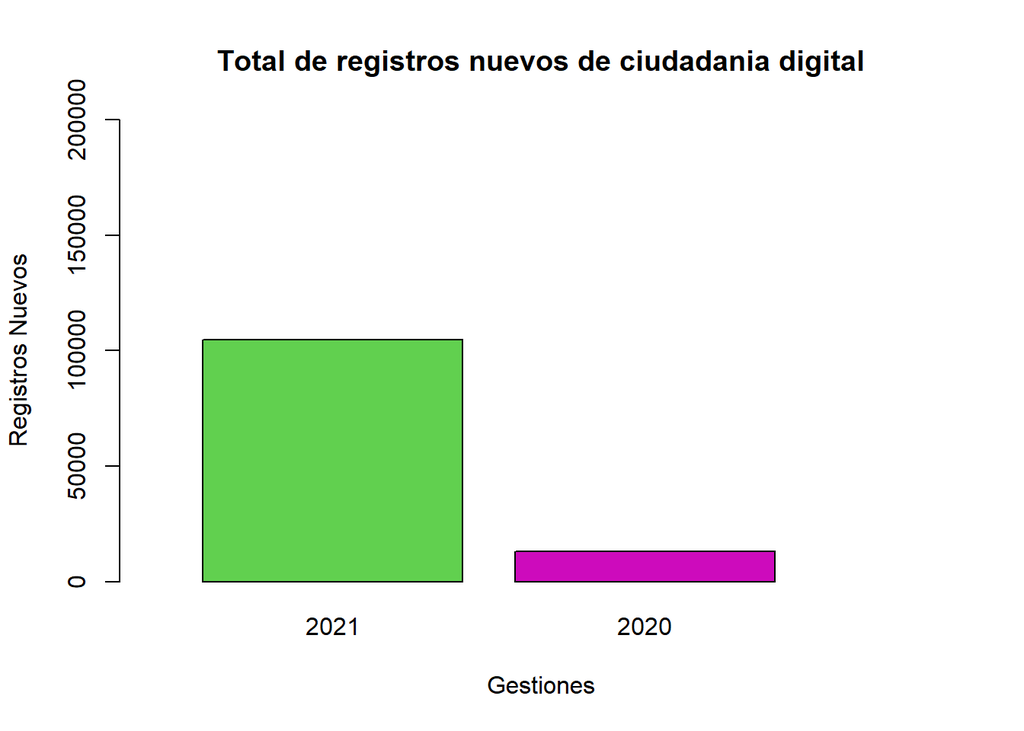

```r
# Cantidad de registros nuevos en las gestiones 2020 y 2021
bp1 <- read.table("preregistros_portal_v2.csv", header=TRUE, sep=";", stringsAsFactors = FALSE)
barplot( bp1$total ,xlab="Gestiones", ylab="Registros Nuevos", xlim = c(0,3),ylim = c(0,200000), names=(bp1$gestion), main = 'Total de registros nuevos de ciudadania digital',col = c(3,6,8))
```

[figure not shown]

```r
## Cantidad de tramites realizados por entidad utilizando la ciudadania digital
bp2 <- read.table("operadores_registro_entidad-1.csv", header=TRUE, sep="|", stringsAsFactors = FALSE)
barplot(bp2$cantidad_operadores, ylab="Cantidad de tramites", ylim = c(0,150),xlab="Entidades", names=bp2$nombre, main = 'Cantidad de tramites por entidad',las=2, col = c(3,6,8))
```

[figure not shown]

```r
## Tramites realizados
pie(bp2$cantidad_operadores, labels = bp2$nombre, col = rainbow(9),main = 'Tramites realizados por entidad')
```

# RESULTADOS DEL PROGRAMA

• Una plataforma sólida, escalable, segura y robusta que permitirá la integración e interacción con distintos servicios electrónicos.

• Información importante de interés contenida en un solo medio de almacenamiento eficiente.

• Información en línea, disponible, accesible, confiable, segura y privada.

• Un medio de acercamiento del gobierno hacia la población.

Con lo beneficios obtenidos los principales beneficiados con la implementación de nuevos sistemas son:

• Población en general

• Entidades del Estado

# REFERENCIAS BIBLIOGRÁFICAS

- https://sites.google.com/site/alfabetidania/caracteristicas-de-la-ciudadania-digital
- https://data.amerigeoss.org/id/dataset/ciudadania-digital1
- https://tsj.bo/ogp/#normativa
- https://coplutic.gob.bo/article29.html
- https://www.asfi.gob.bo/images/MARCO_NORMATIVO/SERV_FINAN_/06LEY_N1080.pdf